# 데이터 과학

단변량/다변량 시계열 데이터

## 1. 시계열 데이터 시각화

`ggplot2` 그래프 문법 방식이 많이 시각화에 사용되고 있지만, R Base 시각화 시스템도 유구한 역사속에 두터운 사용자 층을 확보하고 있고 검증된 다수 시각화 팩키지와 함수를 제공하고 있다. 시계열도 예외는 아니다.

### 1.1. 데이터 가져오기

시계열 데이터를 시각화하는데 필요한 표본 데이터를 불러온다. 제 19 대 대통령 선거에서 다양한 여론조사 업체에서 수집된 정보를 [나무위키](https://namu.wiki/w/%EC%A0%9C19%EB%8C%80%20%EB%8C%80%ED%86%B5%EB%A0%B9%20%EC%84%A0%EA%B1%B0/%EC%97%AC%EB%A1%A0%EC%A1%B0%EC%82%AC)에서 긁어와서 이를 분석에 사용한다.

4개 여론조사업체 중 pdf 파일도 잘 정리해서 제공하고 있는 리얼미터(MBN·매일경제·CBS가 의뢰하여 리얼미터에서 조사한 2017년 대선주자 지지도 주간집계 결과임) 제공 데이터를 활용한다.

```r
# 0. 환경설정 --------------------------------------------------
#library(tidyverse)
#library(rvest)
#library(stringr)
#library(xts)
#library(TTR)
#library(PerformanceAnalytics)
#library(corrplot)

# 1. 데이터 가져오기 ------------------------------------------

namu_url <- "https://namu.wiki/w/%EC%A0%9C19%EB%8C%80%20%EB%8C%80%ED%86%B5%EB%A0%B9%20%EC%84%A0%EA%B1%B0/%EC%97%AC%EB%A1%A0%EC%A1%B0%EC%82%AC"
namu_html <- read_html(namu_url, encoding="UTF-8")

# Sys.setlocale("LC_ALL", "Korean")

real_tbl <- html_table(namu_html) [[8]]

# 2. 데이터 정제 ------------------------------------------

## 2.2. 리얼미터 ----------------------------
names(real_tbl) <- real_tbl[1,]
real_tbl <- real_tbl %>% dplyr::select(`주차`, `문재인`, `홍준표`, `안철수`, `유승민`, `심상정`)

real_df <- real_tbl %>% dplyr::filter(stringr::str_detect(real_tbl$주차, pattern="[0-9]{1}[월]")) %>%
  gather(후보, 지지율, -주차) %>%
  mutate(`지지율` = str_replace_all(`지지율`, "%", "")) %>%
  mutate(`지지율` = as.numeric(`지지율`)) %>%
  mutate(조사업체 = "리얼미터")

write_csv(real_df, "data/survey_real.csv")
```

### 1.2. 문재인 vs. 안철수

제19대 대통령선거에서 가장 관심을 많이 받은 후보가 문재인과 안철수 후보다. 두 후보에 대한 지지율 변화를 시계열 데이터로 변환하여 시각화한다.

가장 먼저 “1월 1주차”와 같은 문자열 정보를 시계열 데이터로 변환시키고 나서, `xts` 자료형으로 변환시킨다. 그리고 시계열 흐름에 맞춰 여러 정보를 그래프 한장에 압축하여 담백하게 담아낸다.

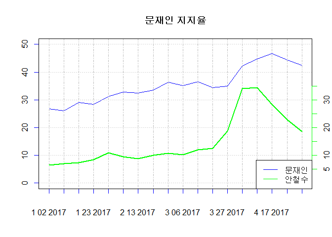

```r
## 3. 데이터 변환 ----------------------------

real_df <- real_dat %>% mutate(week = rep(seq(1:(dim(real_dat)[1]/5)), 5)) %>%
  mutate(weeks = as.Date(paste("1", week, "2017", sep = "-"), format = "%w-%W-%Y")) %>%
  dplyr::select(weeks, 후보, 지지율)

real_wide_df <- real_df %>% tidyr::spread(`후보`, `지지율`)

real_xts <- xts(real_wide_df[,-1], order.by = real_wide_df$weeks)

# 4. 시각화 ----------------------------
## 4.1. 문재인 vs 안철수
plot(real_xts$`문재인`, main="문재인 지지율", col="blue", minor.ticks=FALSE, ylim=c(0,50))
lines(real_xts$`안철수`, col="green", lwd=2)
axis(side=4, at=pretty(real_xts$`안철수`), col="green")

legend(x = "bottomright",
       legend = c("문재인", "안철수"),
       col = c("blue","green"),
       lty = c(1,1))
```

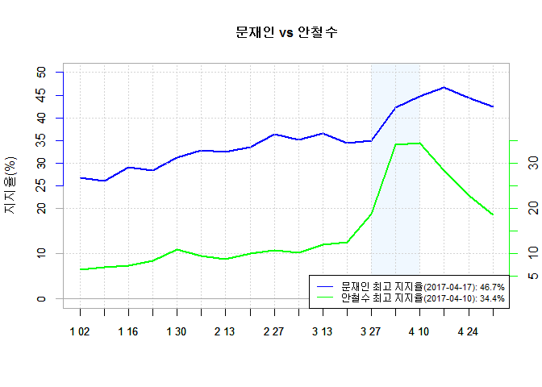

```r
## 4.2. 문재인 vs 안철수 접전
period <- c("2017-03-27/2017-04-10")
par(cex=1)
chart.TimeSeries(real_xts$문재인, period.areas = period, col="blue", ylim=c(0,50), main="문재인 vs 안철수", ylab="지지율(%)")
par(new=TRUE)
chart.TimeSeries(real_xts$`안철수`, col="green", minor.ticks=FALSE, ylim=c(0,50), main="", ylab="")
axis(side=2, at=pretty(real_xts$`문재인`), col="blue")
axis(side=4, at=pretty(real_xts$`안철수`), col="green")

# 주석
moon_max_date <- index(real_xts[which(real_xts$문재인 == max(real_xts$문재인))])
ahn_max_date <- index(real_xts[which(real_xts$안철수 == max(real_xts$안철수))])
moon <- paste0("문재인 최고 지지율(", moon_max_date, "): ", max(real_xts$문재인), "%")
ahn <- paste0("안철수 최고 지지율(", ahn_max_date, "): ", max(real_xts$안철수), "%")

legend(x = "bottomright",
       legend = c(moon, ahn),
       col = c("blue","green"),
       lty = c(1,1), cex=0.7)
```

## 단변량 시계열 분석

시간별 지지율흐름을 살펴본 후에 지지율 변화율을 살펴보는 것도 의미가 크다. 후보별 지지율 시계열 데이터에 대한 변화율을 분석할 경우, 히스토그램, 상자그림, 자기상관함수, 정규성 검정이 사용된다. 이를 각각 시각화하여 살펴보는 것보다 한장의 그래프로 표현하는 방법을 많이 사용한다.

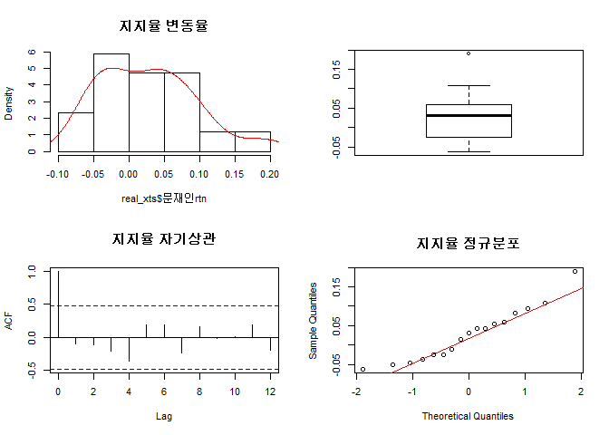

```r
# 3. 시각화 ----------------------------
## 3.1. 문재인 지지율 변화율

real_xts$문재인rtn <- ROC(real_xts$문재인)
real_xts$안철수rtn <- ROC(real_xts$안철수)

par(mfrow=c(2,2), cex=0.7)

hist(real_xts$문재인rtn, probability=TRUE, main="지지율 변동율")
lines(density(real_xts$문재인rtn, na.rm=TRUE), col="red")

boxplot(coredata(real_xts$문재인rtn))

acf(na.omit(coredata(real_xts$문재인rtn)), main="지지율 자기상관")

qqnorm(coredata(real_xts$문재인rtn), main="지지율 정규분포")
qqline(coredata(real_xts$문재인rtn), col="red")
```

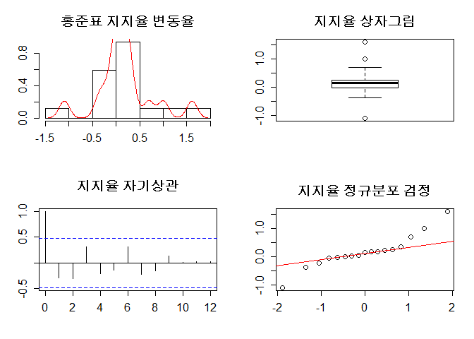

```r
## 3.2. 지지율 변화 함수
change_rate <- function(xts_df) {
  par(mfrow=c(2,2), cex=1, mex=0.7)
  hist(xts_df, probability=TRUE, main=paste(names(xts_df), "지지율 변동율"), xlab="", ylab="")
  lines(density(xts_df, na.rm=TRUE), col="red")

  boxplot(coredata(xts_df), main="지지율 상자그림", xlab="", ylab="")

  acf(na.omit(coredata(xts_df)), main="지지율 자기상관", xlab="", ylab="")

  qqnorm(coredata(xts_df), main="지지율 정규분포 검정", xlab="", ylab="")
  qqline(coredata(xts_df), col="red")
}

change_rate(ROC(real_xts$홍준표))
```

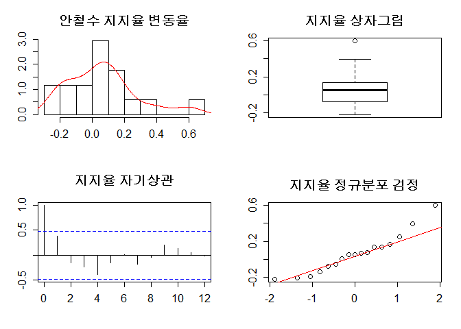

```r
change_rate(ROC(real_xts$안철수))
```

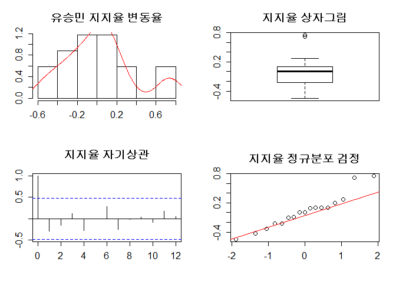

```r
change_rate(ROC(real_xts$유승민))
```

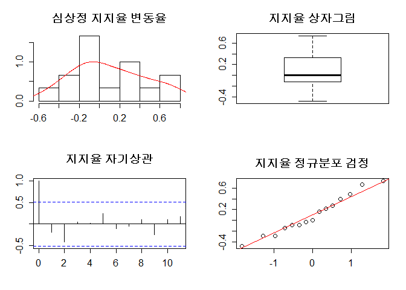

```r
change_rate(ROC(real_xts$심상정))
```

## 다변량 시계열 분석

- `pairs()`
- `corrplot()`

상관계수를 계산할 때 결측값이 존재하기 때문에 `use = "complete.obs"` 인자를 넣어주어야 하고, 기본디폴트 설정은 피어스 상관계수가 후보 지지율 간에 계산된다.

```r
real_xts <- real_xts[, 1:5]

(real_cor_mat <- cor(real_xts, use = "complete.obs"))
```

```
          문재인    심상정    안철수    유승민    홍준표
문재인 1.0000000 0.7619536 0.8654253 0.4157061 0.8000071
심상정 0.7619536 1.0000000 0.5169423 0.5964046 0.9128631
안철수 0.8654253 0.5169423 1.0000000 0.1420244 0.6018729
유승민 0.4157061 0.5964046 0.1420244 1.0000000 0.4122640
홍준표 0.8000071 0.9128631 0.6018729 0.4122640 1.0000000
```

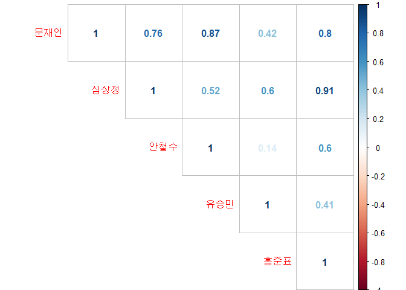

```r
# pairs(coredata(real_xts), lower.panel=NULL)

corrplot(real_cor_mat, method="number", type="upper")
```

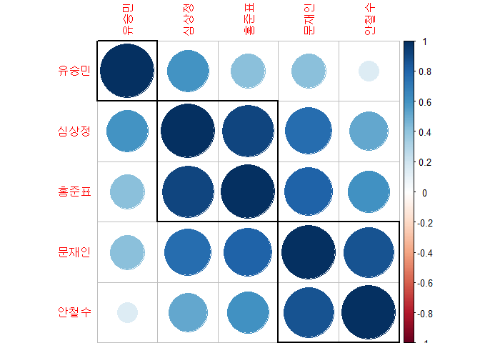

```r
corrplot(real_cor_mat, order="hclust", addrect=3)
```

## 후보별 누적 지지율

앞서 후보를 3개 군집으로 묶어 문재인, 안철수로 묶인 군집내부 누적 지지율 추이를 살펴보고, 동일한 방식으로 홍준표, 유승민 후보에 대한 누적 지지율 추이도 살펴보고 나서, 전체 후보에 대한 누적 지지율 추이도 살펴본다.

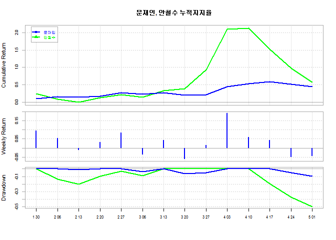

```r
## 3.2. 누적 지지율 추이
real_rtn_xts <- do.call(cbind, lapply(real_xts, TTR::ROC))

charts.PerformanceSummary(real_rtn_xts[5:18, c(1,3)], main="문재인, 안철수 누적지지율", colorset=c("blue", "green"))
```

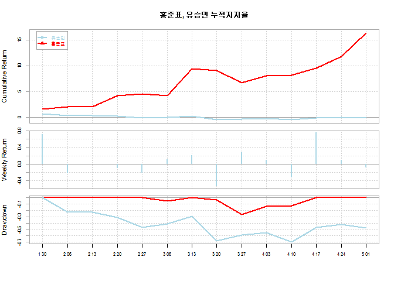

```r
charts.PerformanceSummary(real_rtn_xts[5:18, c(4,5)], main="홍준표, 유승민 누적지지율", colorset=c("lightblue", "red"), lwd=2)
```

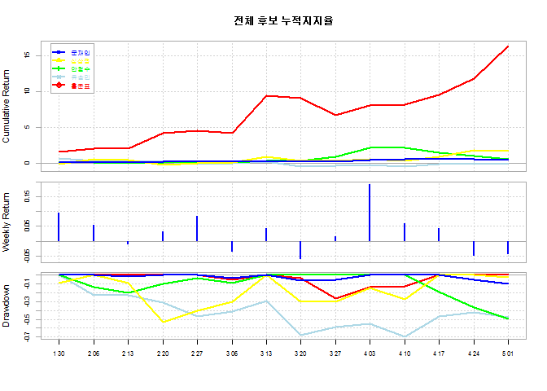

```r
charts.PerformanceSummary(real_rtn_xts[5:18], main="전체 후보 누적지지율", colorset=c("blue", "yellow", "green", "lightblue", "red"), lwd=2)
```